Home > Unsupervised Learning > Autoencoders

# 3.3 Autoencoders

An autoencoder is a particular network architecture allowing to do dimension reduction. The idea is to learn to *encode* some vector $x \in \mathbb{R}^D$ in the feature space by another latent vector $y \in \mathbb{R}^d$, and then decode $y$ into a vector $\hat{x}$ with the hope that $\hat{x} \approx x$. By taking $d \lt \lt D$, it would in principle allow to do dimension reduction. The architecture of a 1-hidden layer neural network is given in this figure

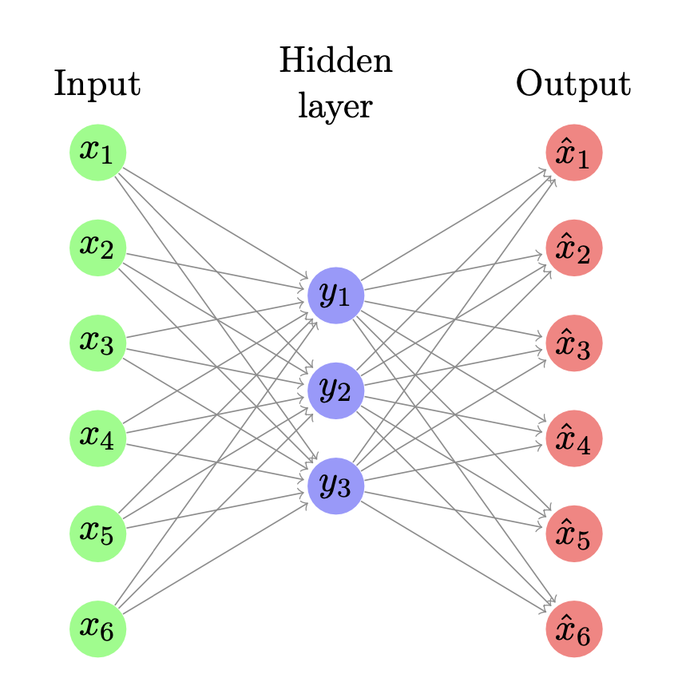

##### Example

Suppose $D = 4, d=2$ $W_1 \in \mathbb{R}^{2 \times 4}$: Maps from $\mathbb{R}^4$ to $\mathbb{R}^2$ (Matrix with 2 rows and 4 columns), $W_2 \in \mathbb{R}^{4 \times 2}$ maps back to $\mathbb{R}^4$ Now multiplying for example
$$W_1 = \begin{bmatrix}
w_{11} & w_{12} & w_{13} & w_{14} \\ w_{21} & w_{22}
& w_{23} & w_{24} \end{bmatrix}, \hspace{0.5cm} x =
\begin{bmatrix}x_1 \\x_2\\x_3\\x_4\end{bmatrix}$$
So multiplying
$$z = W_1 x = \begin{bmatrix}w_{11}x_1 +
w_{12}x_2 + w_{13}x_3 + w_{14}x_4 \\ w_{21}x_1 + w_{22}x_2 + w_{23}x_3 +
w_{24}x_4 \end{bmatrix}$$
results in a $2$ dimensional vector! (reduced dimension). So $W\in\mathbb{R}^{d \times D} x \in \mathbb{R}^D$ results in a $d$-dimensional vector. **Remember**: The number of columns in any matrices $A$ must equal to the number of rows in $B$, else the matrix multiplication won’t work. That’s why the dimension of $W$ are defined like that.

The latent vector is $y = \sigma(W_1x+b_1)$ (compressed representation). In a classical autoencoder, since the purpose is to reconstruct $x$ from itself, the classical loss function is chosen to be, for a dataset $\{x_i\}_{1 \leq i \leq N}$:
$$\mathcal{L}_{AE}(\theta) := \frac{1}{N}
\sum_{i=1}^N || \hat{x_i} - x_i ||^2$$

##### Explanation

You may be wondering why $\theta$ is passed since no parameters are used in the equation but remember that $\hat{x}_i = W_2 \sigma(W_1 x_i + b_1) + b_2$. The reconstruction error $||\hat{x}_i - x_i ||^2$ depends on $\hat{x}_i$ which in turn depends on $\theta$.

**Remember**
$$||v||^2 =
v_1^2 + v_2^2 + ... v_D^2$$
So here, it’s
$$(\hat{x}_{i1}-x_{i1})^2 + (\hat{x}_{i2} - x_{i2})
+ ...$$
where $i$ refers to the $i$-th data point in the dataset. The subscript $1$ or $2$ etc refer to the first component of the vector $x_i$

##### Back to the script (formula)

where $\theta$ denotes the parameters of the network (such as $W_1, b_1, W_2, b_2$ So $\theta = \{W_1, b_1, W_2, b_2\}$).

Minimizing $\mathcal{L}_{AE}$ will force $\hat{x}$ to be as similar as possible to $x$, while being represented by a vector $y$ of lower dimension. (the last part here means that the autoencoder doesnt just reconstruct $x$ directly. Instead, it first compresses $x$ into latent space $y$) Apart from dimension reduction, autoencoders can be used for other purposes, for instance image denoising. **In this setup** (when using autoencoders for image denoising), we perturb ($\sim$ disturb) each data point $x_i$ by some random noise $\epsilon_i$ (usually Gaussian) and learn to reconstruct $x_i$ from the corrupted image $x_i + \epsilon_i$ by minimizing
$$\mathcal{L}_{AE} := \frac{1}{N}
\sum_{i=1}^N || \hat{f}(x_i + \epsilon_i) - x_i ||^2$$
($\hat{f}(x_i + \epsilon_i)$ just returns a reconstructed *denoised* image). By minimizing $L_{AE}$ the autoencoder learns to remove noise and reconstruct the original image! While usually, autoencoders verifies the bottleneck property (latent representation) $d \lt \lt D$, it may be interesting to allow for $d \geq D$ (latent space can be larger than input space) while forcing some sparsity on $y$.

##### What does sparsity mean?

Sparsity (=spärlich) means most of the elements in the latent vector $y$ are **zero** or close to zero This forces the autoencoder to **focus** on a small number of **important** features in the data, rather than using all available dimensions.

##### Back to the script

This can be achieved by taking the loss $\mathcal{L} = \mathcal{L}_{AE} + \mathcal{L}_{sp}$ ($\mathcal{L}_{sp}$ is the sparsity penalty) penalizes large values $y_i = \sigma(W_1 x_i + b_i)$. For instance,
$$\mathcal{L}_{sp}(\theta) =\frac{1}{N}
\sum_{i=1}^N ||y_i||_1$$
leads to the $L^1$-sparse autoencoder.

##### Explanation

$||y_i||_1$ Is the sum of absolute values of the elements in $y_i$. $y_i$ is the **latent representation** of the $i$-th data point. $||y_i||_1$ is the $L^1$-norm of $y_i$, which is the sum of absolute values of its elements. For example (values are just imaginary): $||y_i||_1 = |0.1| + |-0.3| + |0.0| +|0.7| = 1.1$ Minimizing $\mathcal{L}_{sp}$ encourages $y_i$ to have many zeros. $L_{sp}$ is the average $L^1$-norm over all data points in the dataset (bc we average $||y_i||_1$ over all data points!)

## 3.3.1 Linear autoencoder

In this section, we treat the case of linear autoencoder, i.e. the case where $\sigma$ is the identity function ($\sigma(z) = z)$. This case may seem uninteresting at first glance, but we will see that it nicely links to a previously seen algorithm. In this particular case, the network reduces to
$$\hat{f}(x) =
W_2\sigma(W_1x + b_1) + b_2$$
Since $\sigma(z) = z$, just multiply everything out:
$$\hat{f}(x) = W_2 W_1x + W_2 b_1 +
b_2$$
while the loss is
$$\mathcal{L}_{AE}(b_1, b_2, W_1, W_2) =
\frac{1}{N} \sum_{i=1}^N ||W_2W_1x_i+W_2b_1+b_2-x_i||^2$$
(Notice that above we had $\theta$ but here since $\sigma$ is the identity function we can just substitute $\hat{x}_i$ with our network) and we aim at solving
$$\min_{b_1, b_2, W_1, W_2}
\mathcal{L}_{AE}(b_1, b_2, W_1, W_2)$$
We want to make the optimization easier, first we eliminate $b_2$ because this reduces the number of variables we need to optimize. First, by taking the gradient w.r.t $b_2$ and using the optimality condition $\nabla_{b_2} \mathcal{L}_{AE} = 0$, we get that $b_2 = \overline{x} - W_2W_1 \overline{x} - W_2 b_1$.

##### Gradient calculation

$$\nabla_{b_2}\mathcal{L}_{AE} =
\frac{2}{N}\sum_{i=1}^N (W_2W_1x_i+W_2b_1+b_2 - x_i)$$
Setting the gradient to zero:
$$\frac{2}{N}\sum_{i=1}^N (W_2W_1x_i+W_2b_1+b_2 -
x_i) = 0$$
Simplifying:
$$\sum_{i=1}^N
(W_2W_1x_i+W_2b_1+b_2 - x_i) = 0$$
Splitting the sum:
$$W_2W_1 \sum_{i=1}^N x_i + W_2b_1N +
b_2N-\sum_{i=1}^Nx_i = 0$$
Let $\overline{x} = \frac{1}{N}\sum_{i=1}^N x_i$ (mean of data points, then)
$$W_2W_1(N \overline{x}) + W_2b_1N + b_2N - N
\overline{x} = 0$$
Dividing by $N$:
$$W_2W_1\overline{x} + W_2b_1 + b_2 - \overline{x}
= 0$$
Solving for $b_2$:
$$b_2 = \overline{x} -W_2W-\overline{x} -
W_2b_1$$

##### Back to the script

Thus the problem is reduced to
$$\min_{W_1, W_2} \frac{1}{N} \sum_{i=1}^N ||W_2
W_1(x_i - \overline{x}) - (x_i - \overline{x})||^2$$

##### Expanded version

$$\min_{W_1, W_2} \frac{1}{N} \sum_{i=1}^N
||W_2W_1x_i + W_2b_1 + (\overline{x} -W_2W_1-\overline{x} - W_2b_1) -
x_i||^2$$
(substituted $b_2$ here into original loss function) Notice that
$$W_2W_1x_i+W_2b_1+\overline{x}-W_2W_1-\overline{x}-W_2b_1-x_i$$
needs to be simplified. Notice that $W_2b_1$ and $-W_2b_1$ cancel out:
$$W_2W_1x_i + \overline{x} - W_2W_1 \overline{x} -
x_i = W_2W_1x_i-W_2W_1\overline{x}+\overline{x}-x_i$$
Factoring out we get
$$W_2W_1(x_i-\overline{x}) +
\overline{x} - x_i$$
We can rewrite the last two terms and thus get
$$W_2W_1(x_i - \overline{x}) - (x_i -
\overline{x})$$

##### Back to the script

$$\min_{W_1, W_2} \frac{1}{N} \sum_{i=1}^N
||W_2 W_1(x_i - \overline{x}) - (x_i - \overline{x})||^2$$
Note that both the dependency in $b_2$ and $b_1$ have disappeared. Now let $X_0 \in \mathbb{R}^{D \times N}$ be the matrix having $x_i-\overline{x}$ as the $i$-th column. The previous optimization problem can be rewritten as (dropping the $1/N$ factor because scaling doesn’t affect the minimization)
$$\min_{W_2}\min_{W_1}
||W_2 W_1 X_0 - X_0 ||^2_{\text{Fro}}$$
We now aim at finding a closed-form solution of the inner problem
$$\min_{W_1} ||W_2 W_1 X_0 - X_0
||^2_{\text{Fro}}$$

Let $\phi(W_1) = ||W_2 W_1 X_0 - X_0||^2_\text{Fro}$. We recall that the gradient of $\phi$ at $W_1$ is defined as the matrix $\nabla \phi(W_1)$ such that for all $H \in \mathbb{R}^{d \times D}$, $D\phi(W_1).H = \langle \phi(W_1), H \rangle_{\text{Fro}} = Tr(\nabla \phi(W_1)H^T)$. Going back to the definition of the differential, we can show that
$$\nabla \phi(W_1) = 2 X_0 (X_0 - W_2 W_1 X_0)^T
W_2$$
Hence, the optimality condition is $X_0X_0^T W_2 = X_0 X_0^TW_1^TW_2^tW_2$. Remark that the matrix $X_0 X_0^T$ is the covariance matrix of the data. Under the assumption that this matrix is invertible, the previous optimality conditions reduces to
$$W_2^T = W_2^T W_2 W_1$$

#### Lemma 3.3.1

Let $A \in \mathbb{R}^{n \times m}$. Then
$$A^T = A^TA
A^\dagger$$
Proof: Write the SVD $A = U\Sigma V^T$ First calculate $A^TA$
$$A^T =
(U \Sigma V^T)^T = (V \Sigma^T U^T), \hspace{0.5cm} A = (U \Sigma
V^T)$$
$$A^TA = (V\Sigma ^T
U^T)(U\Sigma V^T) = V\Sigma^T \Sigma V^T$$
Now compute $A^\dagger$
$$A^\dagger = (V \Sigma^\dagger U^T)$$
$$\begin{align}
A^TA A^\dagger &= (V\Sigma^T\Sigma V^T)(V\Sigma^\dagger U^T) \\
&= V\Sigma^T \Sigma \Sigma^\dagger U^T
\end{align}$$
Now lets look at $\Sigma^T\Sigma \Sigma^\dagger$ We know that $\Sigma^\dagger$ is $\frac{1}{\sigma_k}$ on its diagonal and $\Sigma$ is $\sigma_k$ on its diagonal, thus $\Sigma \Sigma^\dagger = I$ and we get:
$$A^T A^\dagger = V \Sigma^TU^T =
A^T$$
The previous lemma allows us to take $W_1 = W_2^\dagger$, which further reduces the problem to

#### 3.3.1

$$\min_{W_2} ||W_2 W_2^\dagger X_0 - X_0
||^2_\text{Fro}$$

#### Proposition 3.3.1

#3.3.1 is equivalent to

#### 3.3.2

$$\max_{W_2} Tr(W_2^\dagger X_0 X_0^T
W_2)$$
Proof: Developing:
$$||W_2
W_2^\dagger X_0 - X_0||^2_\text{Fro} = ||X_0||^2_\text{Fro} - 2\langle
X_0, W_2, W_2^\dagger X_0\rangle_\text{Fro} + ||W_2 W_2^\dagger
X_0||^2_\text{Fro}$$
we can rewrite $\langle X_0, W_2, W_2^\dagger X_0\rangle_\text{Fro} = Tr(W_2W_2^\dagger X_0 X_0^T) = Tr(W_2^\dagger X_0 X_0^T W_2)$ In a similar way,
$$\begin{align}
||W_2 W_2^\dagger X_0||_\text{Fro}^2 &= Tr((W_2W_2^\dagger
X_0)(W_2W_2^\dagger X_0)^T)
\\
&= Tr(W_2W_2^\dagger X_0X_0^T (W_2^\dagger)^T W_2^T) \\
&= Tr(W_2^\dagger X_0 X_0^T (W_2^\dagger)^T W_2^T W_2) \\
&= Tr(W_2^\dagger X_0 X_0^TW_2)
\end{align}$$
where we **used the fact that** $(W_2^\dagger)^TW_2^TW_2 = W_2$ using the previous Lemma. Hence, #3.3.1 can be rewritten as
$$\min_{W_2}
||X_0||^2_\text{Fro} - Tr(W_2^\dagger X_0 X_0^TW_2)$$
which is equivalent to #3.3.2 We now restrict to the extreme case where $d=1$. In this case $W_2 = w_2 \in \mathbb{R}^D$. By noticing that for all $w_2, Tr(w_2^\dagger X_0 X_0^T w_2) = ||w_2 w_2^\dagger X_0||^2_\text{Fro} \geq 0$, we can assume that $w_2 \neq 0$. In this case, $w_2^\dagger = \frac{1}{||w_2||^2_2}w_2^T$ and thus the problem becomes
$$\max_{w_2 \in \mathbb{R}^D \textbackslash \{0\}}
\frac{w_2^T X_0X_0^T w_2}{||w_2||^2_2}$$
which is equivalent to
$$\max_{||w_2||_2 = 1} w_2^T X_0 X_0^T
w_2$$
As we have seen in the exercises, the optimal $w_2$ is nothing else that the first eigenvalue of the covariance matrix $X_0 X_0^T$. In other words: a linear autoencoder performs PCA! With a little more work it is possible to show that this is actually the case for all $d \in \{1,..., D\}$. Hence, a general (nonlinear) autoencoder can be seen as a generaliztion of the PCA